# Integration of renewable energy sources

August 21, 2023

## Overview

Renewables are a field of interest to an increasing amount of public entities, and as such it poses the following questions:

1. How should renewables be bond with the industry not to undermine quality of life?
2. How are investments in renewables related to their effective adoption and to the available resources?
3. What are the growth prospects of renewables with respect to fossil fuels?

## The datasets

The datasets used to answer these questions incorporate the relationship between all the countries, the year (this analysis will focus on the period between 2000 and 2020) and multiple quantities. These quantities are:

1. Energy production from oil, gas, coal, wind, solar, hydroelectric and nuclear.
2. Economic and financial indicators, in this case GDP and public investments in renewables.
3. Demographic indicators such as population size and life expectancy.
4. CO2 emissions.

## The deep relation between fossil fuels’ usage and CO2 emissions

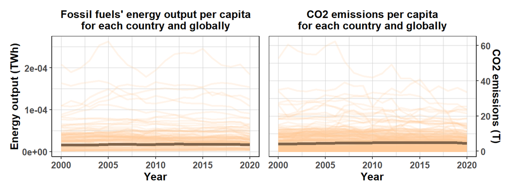

Fossil fuels’ usage and CO2 emissions not only both increased in the last decades, but they also grew following the same pattern.

Globally, fossil fuels’ usage has gone from 1.5e-5TWh to 1.7e-5TWh per capita, while CO2 emissions have gone from 4.1T to 4.5T per capita, a slight worsening that, multiplied by the increasing population, turns into a much more serious deal.

## The deep relation between fossil fuels’ usage and GDP per capita

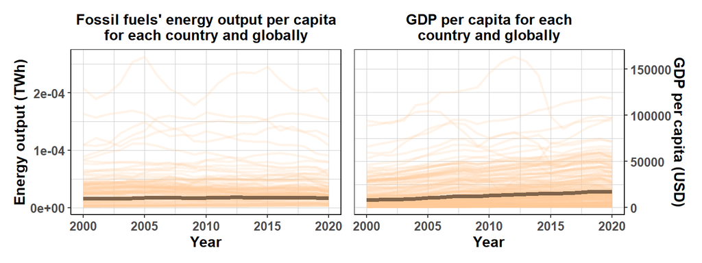

The modern industry, whose development is associated to the GDP per capita trend, has grown in the same fashion as fossil fuels’ usage, but in an amplified manner.

Global GDP per capita has grown from 8214USD in 2000 to 17009USD per capita in 2020.

## The deep relation between GDP per capita and life expectancy

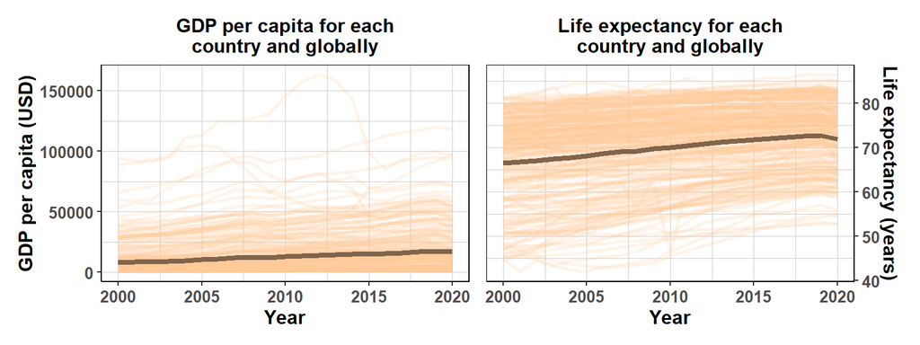

Boosting industry activity improves quality of life, bringing life expectancy up from 67 to 72 years average globally, as industrial and scientific development bring solutions to humanity’s troubles.

Renewables will reduce pollution and CO2 emissions, further improving quality of life, but the replacement needs to be planned not to harm industry activity.

## Public investments in renewables

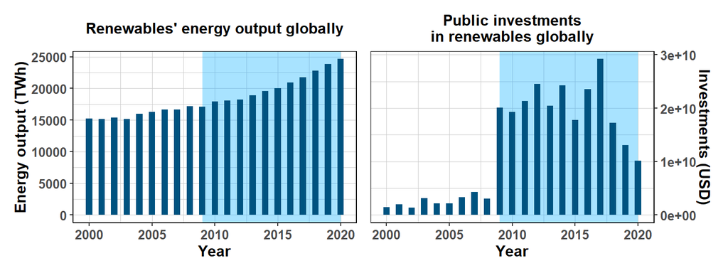

Governments’ interest in renewables rose in 2009 with a sudden increase in public investments. Since then renewables’ employment has accelerated thanks to legal incentives.

This commitment, however, faded a lot from 2018 forward, after a peak in 2017 of 30 billion USD globally, declined to 10 billion USD in 2020.

## Performance of investments

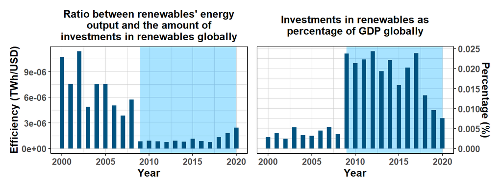

The high starting efficiency (a relative measure not meant to be read with absolute units) up to 2008 is due to the low funding. The middle part from 2009 to 2017 is shallow and uniform because of constant funding, while from 2018 it has grown again, because of long lead times from previous investments and their subsequent decrease.

With respect to the global GDP, public investments before 2009 went from 0.0025% to 0.005%, they peaked in 2012 at 0.025% and then declined to 0.0075% in 2020.

## Renewables’ share in total energy supply

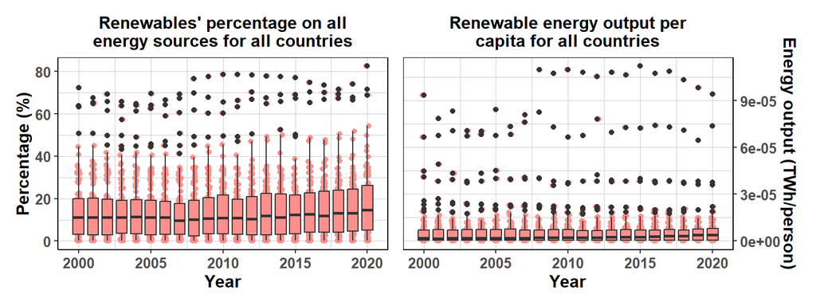

Taking into consideration the great variability from country to country, in 2000 14% of the total energy output was renewable, with 2.5e-6TWh produced per capita. This percentage fell down to 13% in 2009 (the amount of renewable energy produced per capita remained the same) and then, thanks to more involved governments, it grew up again reaching 16% in 2020, with an increased 3.1e-6TWh produced per capita.

## Forecast on renewables’ share in the future

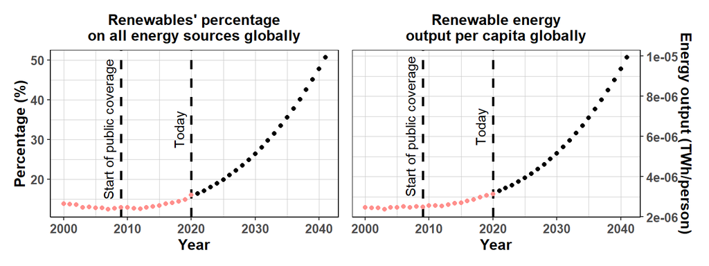

Following the global trend outlined in the previous plot, renewables’ production is projected to surpass fossil fuels’ by 2041 according to a cubic regression (RSE 0.18) with a production of 9.9e-6TWh per capita.

## Conclusions

1. Renewable energy sources will undoubtedly improve quality of life thanks to reduced emissions and pollution. However, quality of life is nowadays deeply connected to the activity of the industrial complex, which is in turn related to fossil energy sources. Thus, forcing a transition before increasing investments in renewables (but also in infrastructures for energy delivery) will result in an abrupt loss in life expectancy. An example could be the forcing of an all electric vehicles’ market by 2035 in EU without deploying energy facilities in enough volume and capacity or enough charging stations to support the whole fleet. It is unthinkable to force such a transition without building the adequate infrastructure first.
2. Government support to renewawbles’ research and implementation through public investments is a tiny part of the related finance. A massive increase in government support (even 100 fold) is required not only with actual economic assistance to the businesses, but also in the form of alleviating the bureaucratic procedures that prevents accessible renewables’ adoption, which would be made more convenient.
3. Since the increase of public investments we’ve seen an increase of about 3% in renewables usage on all energy sources. This given, and in light of the late decrease in investments, if governments don’t keep their involvement with incentives and structural allowance expectations might be further delayed.

## Links

Energy sources

https://ourworldindata.org/energy

Investments

https://www.irena.org/Data/View-data-by-topic/Finance-and-Investment/Renewable-Energy-Finance-Flows

CO2 emissions

https://ourworldindata.org/co2-dataset-sources

GDP

https://www.imf.org/external/datamapper/NGDP_RPCH@WEO/OEMDC/ADVEC/WEOWORLD

Population

https://ourworldindata.org/grapher/population